# **Milestone 2**

## **Model Building**

1. What we want to predict is the "Price". We will use the normalized version 'price_log' for modeling.
2. Before we proceed to the model, we'll have to encode categorical features. We will drop categorical features like Name.
3. We'll split the data into train and test, to be able to evaluate the model that we build on the train data.
4. Build Regression models using train data.
5. Evaluate the model performance.

**Note:** Please load the data frame that was saved in Milestone 1 here before separating the data, and then proceed to the next step in Milestone 2.

### **Load the data**

```python
import pandas as pd

cars_data = pd.read_csv("cars_data_updated.csv")
```

### **Split the Data**

Step1: Seperating the indepdent variables (X) and the dependent variable (y).

Step2: Encode the categorical variables in X using pd.dummies.

Step3: Split the data into train and test using train_test_split.

**Think about it:** Why we should drop 'Name','Price','price_log','Kilometers_Driven' from X before splitting?

```python
# Libraries
import numpy as np
import matplotlib.pyplot as plt
import seaborn as sns

# Regression models:
from sklearn.linear_model import LinearRegression  # For linear regression model
from sklearn.tree import DecisionTreeRegressor     # For decision tree model
from sklearn.linear_model import Ridge             # For Ridge / Lasso Regression
from sklearn.ensemble import RandomForestRegressor # For Random Forest regressor

# Metrics to evaluate the model
from sklearn.metrics import confusion_matrix, classification_report, f1_score
from sklearn.datasets import make_regression
from sklearn import metrics

from sklearn.model_selection import train_test_split
from sklearn import tree

# For hyperparameter tuning
from sklearn.model_selection import GridSearchCV
from sklearn.preprocessing import StandardScaler
```

```python
#familiarizing with dataset
cars_data.describe().T
```

|  | count | mean | std | min | 25% | 50% | 75% | max |
| --- | --- | --- | --- | --- | --- | --- | --- | --- |
| Year | 6018.0 | 2013.357594 | 3.269677 | 1998.000000 | 2011.000000 | 2014.000000 | 2016.000000 | 2019.000000 |
| Kilometers_Driven | 6018.0 | 57668.047690 | 37878.783175 | 171.000000 | 34000.000000 | 53000.000000 | 73000.000000 | 775000.000000 |
| Mileage | 6018.0 | 18.135329 | 4.581823 | 0.000000 | 15.170000 | 18.160000 | 21.100000 | 33.540000 |
| Engine | 6018.0 | 1618.510469 | 600.234304 | 72.000000 | 1197.000000 | 1493.000000 | 1969.000000 | 5998.000000 |
| Power | 6018.0 | 112.296265 | 53.537215 | 34.200000 | 74.000000 | 91.100000 | 138.030000 | 560.000000 |
| Seats | 6018.0 | 5.277999 | 0.803837 | 2.000000 | 5.000000 | 5.000000 | 5.000000 | 10.000000 |
| Price | 6018.0 | 9.470243 | 11.165926 | 0.440000 | 3.500000 | 5.640000 | 9.950000 | 160.000000 |
| kilometers_driven_log | 6018.0 | 10.757961 | 0.713022 | 5.141664 | 10.434116 | 10.878047 | 11.198215 | 13.560618 |
| price_log | 6018.0 | 1.824705 | 0.873606 | -0.820981 | 1.252763 | 1.729884 | 2.297573 | 5.075174 |

```python
#checking for null values
cars_data.isnull().sum()
```

```
Name                     0
Location                 0
Year                     0
Kilometers_Driven        0
Fuel_Type                0
Transmission             0
Owner_Type               0
Mileage                  0
Engine                   0
Power                    0
Seats                    0
Price                    0
Brand                    0
Model                    0
kilometers_driven_log    0
price_log                0
dtype: int64
```

```python
cars_data.describe(include='object')
```

|  | Name | Location | Fuel_Type | Transmission | Owner_Type | Brand | Model |
| --- | --- | --- | --- | --- | --- | --- | --- |
| count | 6018 | 6018 | 6018 | 6018 | 6018 | 6018 | 6018 |
| unique | 1876 | 11 | 5 | 2 | 4 | 30 | 211 |
| top | Mahindra XUV500 W8 2WD | Mumbai | Diesel | Manual | First | maruti | swift |
| freq | 49 | 790 | 3204 | 4299 | 4928 | 1211 | 353 |

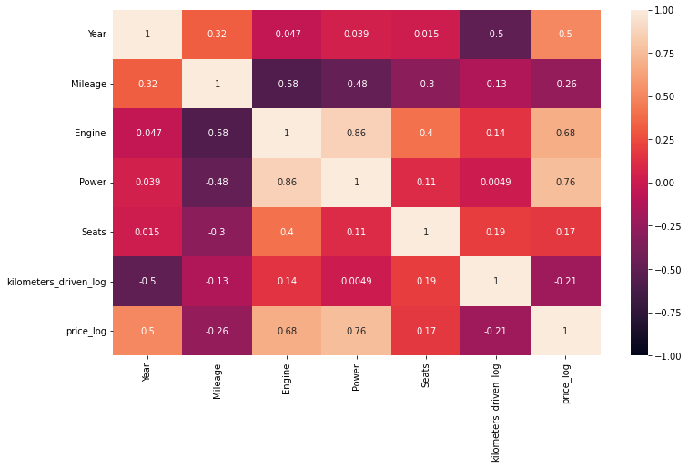

```python
#I used a heatmap to understand the relationships and correlations between the variables.
#We notice that Power, Engine, Year have the highest correlation with our variable of interest “price_log.”

plt.figure(figsize = (12, 7))

sns.heatmap(cars_data.drop(['Price', 'Kilometers_Driven'],axis = 1).corr(), annot = True, vmin = -1, vmax = 1)

plt.show()
```

```python
#looking at the mean price for each brand of cars
cars_data.groupby(["Brand"])["Price"].mean().sort_values(ascending=False)
```

```
Brand
lamborghini      120.000000
bentley           59.000000
porsche           48.348333
land              39.259500
jaguar            37.632250
mini              26.896923
mercedes-benz     26.809874
audi              25.537712
bmw               25.093684
volvo             18.802857
jeep              18.718667
isuzu             14.696667
toyota            11.580024
mitsubishi        11.058889
force              9.333333
mahindra           8.045919
skoda              7.559075
ford               6.889400
renault            5.799034
honda              5.411743
hyundai            5.343433
volkswagen         5.307270
nissan             4.738352
maruti             4.517267
tata               3.562849
fiat               3.269286
datsun             3.049231
chevrolet          3.044463
smart              3.000000
ambassador         1.350000
Name: Price, dtype: float64
```

```python
# Step-1
X = cars_data.drop(['Name','Price','price_log','Kilometers_Driven'], axis = 1)

y = cars_data[["price_log", "Price"]]
```

```python
# Step-2 Use pd.get_dummies(drop_first = True)
X = pd.get_dummies(X, drop_first = True)
```

```python
# Step-3 Splitting data into training and test set:
X_train, X_test, y_train, y_test = train_test_split(X, y, test_size = 0.3, random_state = 1)

print(X_train.shape, X_test.shape)
```

```
(4212, 263) (1806, 263)
```

```python
# Writing a function for calculating r2_score and RMSE on train and test data
# This function takes model as an input on which we have trained particular algorithm
# The categorical column as the input and returns the boxplots and histograms for the variable

def get_model_score(model, flag = True):
    '''
    model : regressor to predict values of X

    '''
    # Defining an empty list to store train and test results
    score_list = []

    pred_train = model.predict(X_train)

    pred_train_ = np.exp(pred_train)

    pred_test = model.predict(X_test)

    pred_test_ = np.exp(pred_test)

    train_r2 = metrics.r2_score(y_train['Price'], pred_train_)

    test_r2 = metrics.r2_score(y_test['Price'], pred_test_)

    train_rmse = metrics.mean_squared_error(y_train['Price'], pred_train_, squared = False)

    test_rmse = metrics.mean_squared_error(y_test['Price'], pred_test_, squared = False)

    # Adding all scores in the list
    score_list.extend((train_r2, test_r2, train_rmse, test_rmse))

    # If the flag is set to True then only the following print statements will be dispayed, the default value is True
    if flag == True:

        print("R-sqaure on training set : ", metrics.r2_score(y_train['Price'], pred_train_))

        print("R-square on test set : ", metrics.r2_score(y_test['Price'], pred_test_))

        print("RMSE on training set : ", np.sqrt(metrics.mean_squared_error(y_train['Price'], pred_train_)))

        print("RMSE on test set : ", np.sqrt(metrics.mean_squared_error(y_test['Price'], pred_test_)))

    # Returning the list with train and test scores
    return score_list
```

For Regression Problems, some of the algorithms used are :

**1) Linear Regression**  
**2) Ridge / Lasso Regression**  
**3) Decision Trees**  
**4) Random Forest**

### **Fitting a linear model**

Linear Regression can be implemented using:

**1) Sklearn:** https://scikit-learn.org/stable/modules/generated/sklearn.linear_model.LinearRegression.html  
**2) Statsmodels:** https://www.statsmodels.org/stable/regression.html

```python
# Create a linear regression model
lr = LinearRegression()
```

```python
# Fit linear regression model
lr.fit(X_train, y_train['price_log'])
```

```
LinearRegression()
```

```python
# Get score of the model
LR_score = get_model_score(lr)
```

```
R-sqaure on training set :  0.9405443096513909
R-square on test set :  0.8791796165653779
RMSE on training set :  2.724256408931264
RMSE on test set :  3.8739101364088144
```

**Observations from results: **_****

- Our model has a high r-squared value, which is equal 0.94, but unfortunately r-squared for the test set is lower.
- This means that our model is overfitting

**Important variables of Linear Regression**

Building a model using statsmodels.

```python
# Import Statsmodels
import statsmodels.api as sm

# Statsmodel api does not add a constant by default. We need to add it explicitly
x_train = sm.add_constant(X_train)

# Add constant to test data
x_test = sm.add_constant(X_test)

def build_ols_model(train):

    # Create the model
    olsmodel = sm.OLS(y_train["price_log"], train)

    return olsmodel.fit()


# Fit linear model on new dataset
olsmodel1 = build_ols_model(x_train)

print(olsmodel1.summary())
```

```
                            OLS Regression Results
==============================================================================
Dep. Variable:              price_log   R-squared:                       0.959
Model:                            OLS   Adj. R-squared:                  0.956
Method:                 Least Squares   F-statistic:                     407.6
Date:                Thu, 06 Oct 2022   Prob (F-statistic):               0.00
Time:                        20:59:47   Log-Likelihood:                 1317.6
No. Observations:                4212   AIC:                            -2179.
Df Residuals:                    3984   BIC:                            -732.4
Df Model:                         227
Covariance Type:            nonrobust
=============================================================================================
                                coef    std err          t      P>|t|      [0.025      0.975]
---------------------------------------------------------------------------------------------
const                      -204.4926      2.877    -71.069      0.000    -210.134    -198.851
Year                          0.1073      0.001     72.710      0.000       0.104       0.110
Mileage                      -0.0007      0.001     -0.452      0.651      -0.004       0.002
Engine                    -8.661e-05   2.19e-05     -3.956      0.000      -0.000   -4.37e-05
Power                         0.0024      0.000     10.163      0.000       0.002       0.003
Seats                         0.0014      0.015      0.093      0.926      -0.027       0.030
kilometers_driven_log        -0.0736      0.006    -13.074      0.000      -0.085      -0.063
Location_Bangalore            0.1852      0.019      9.850      0.000       0.148       0.222
Location_Chennai              0.0593      0.018      3.305      0.001       0.024       0.094
Location_Coimbatore           0.1532      0.017      8.955      0.000       0.120       0.187
Location_Delhi               -0.0811      0.017     -4.686      0.000      -0.115      -0.047
Location_Hyderabad            0.1478      0.017      8.870      0.000       0.115       0.181
Location_Jaipur              -0.0193      0.018     -1.051      0.293      -0.055       0.017
Location_Kochi               -0.0173      0.017     -1.012      0.311      -0.051       0.016
Location_Kolkata             -0.2193      0.018    -12.509      0.000      -0.254      -0.185
Location_Mumbai              -0.0507      0.017     -3.049      0.002      -0.083      -0.018
Location_Pune                -0.0236      0.017     -1.379      0.168      -0.057       0.010
Fuel_Type_Diesel              0.0594      0.033      1.812      0.070      -0.005       0.124
Fuel_Type_Electric           -0.2914      0.088     -3.329      0.001      -0.463      -0.120
Fuel_Type_LPG                -0.0623      0.076     -0.815      0.415      -0.212       0.088
Fuel_Type_Petrol             -0.0596      0.034     -1.767      0.077      -0.126       0.007
Transmission_Manual          -0.1175      0.010    -11.475      0.000      -0.138      -0.097
Owner_Type_Fourth & Above    -0.1149      0.087     -1.321      0.187      -0.285       0.056
Owner_Type_Second            -0.0550      0.008     -6.531      0.000      -0.072      -0.039
Owner_Type_Third             -0.1347      0.022     -6.092      0.000      -0.178      -0.091
Brand_audi                   -6.9817      0.112    -62.132      0.000      -7.202      -6.761
```

[output cut: 234 more lines]

```
Model_yeti                   -0.9708      0.068    -14.250      0.000      -1.104      -0.837
Model_z4                      0.8746      0.217      4.032      0.000       0.449       1.300
Model_zen                    -0.9390      0.074    -12.755      0.000      -1.083      -0.795
Model_zest                   -0.9395      0.107     -8.741      0.000      -1.150      -0.729
==============================================================================
Omnibus:                     1982.883   Durbin-Watson:                   2.019
Prob(Omnibus):                  0.000   Jarque-Bera (JB):           120844.480
Skew:                          -1.433   Prob(JB):                         0.00
Kurtosis:                      29.084   Cond. No.                     7.63e+19
==============================================================================

Notes:
[1] Standard Errors assume that the covariance matrix of the errors is correctly specified.
[2] The smallest eigenvalue is 4.95e-30. This might indicate that there are
strong multicollinearity problems or that the design matrix is singular.
```

```python
# Retrive Coeff values, p-values and store them in the dataframe
olsmod = pd.DataFrame(olsmodel1.params, columns = ['coef'])

olsmod['pval'] = olsmodel1.pvalues
```

```python
# Filter by significant p-value (pval <= 0.05) and sort descending by Odds ratio

olsmod = olsmod.sort_values(by = "pval", ascending = False)

pval_filter = olsmod['pval']<= 0.05

olsmod[pval_filter]
```

|  | coef | pval |
| --- | --- | --- |
| Model_verna | 0.253587 | 0.041950 |
| Model_getz | -0.286947 | 0.035724 |
| Model_accent | -0.292885 | 0.029862 |
| Model_s-class | -0.256333 | 0.021635 |
| Model_s-cross | -0.449056 | 0.018093 |
| ... | ... | ... |
| Brand_porsche | -5.408007 | 0.000000 |
| Brand_nissan | -7.712777 | 0.000000 |
| Brand_mitsubishi | -6.705807 | 0.000000 |
| Brand_mini | -5.918719 | 0.000000 |
| const | -204.492597 | 0.000000 |

231 rows × 2 columns

```python
# We are looking are overall significant varaible

pval_filter = olsmod['pval']<= 0.05
mp_vars = olsmod[pval_filter].index.tolist()

# We are going to get overall varaibles (un-one-hot encoded varables) from categorical varaibles
sig_var = []
for col in mp_vars:
    if '' in col:
        first_part = col.split('_')[0]
        for c in cars_data.columns:
            if first_part in c and c not in sig_var :
                sig_var.append(c)


start = '\033[1m'
end = '\033[95m'
print(start+ 'Most overall significant categorical varaibles of LINEAR REGRESSION  are ' +end,':\n', sig_var)
```

```
Most overall significant categorical varaibles of LINEAR REGRESSION  are  :
 ['Model', 'Location', 'Fuel_Type', 'Engine', 'Owner_Type', 'Power', 'Transmission', 'kilometers_driven_log', 'Brand', 'Year']
```

```python
from sklearn.model_selection import cross_val_score

# Build the regression model and cross-validate
linearregression = LinearRegression()

cv_Score11 = cross_val_score(linearregression, X_train, y_train, cv = 10)
cv_Score12 = cross_val_score(linearregression, X_train, y_train, cv = 10,
                             scoring = 'neg_mean_squared_error')


print("RSquared: %0.3f (+/- %0.3f)" % (cv_Score11.mean(), cv_Score11.std() * 2))
print("Mean Squared Error: %0.3f (+/- %0.3f)" % (-1*cv_Score12.mean(), cv_Score12.std() * 2))
```

```
RSquared: 0.885 (+/- 0.055)
Mean Squared Error: 11.342 (+/- 10.729)
```

**Build Ridge / Lasso Regression similar to Linear Regression:**

https://scikit-learn.org/stable/modules/generated/sklearn.linear_model.Ridge.html

```python
# Ridge regression model
rdg=Ridge()
rdg.fit(X_train, y_train['price_log'])
```

```
Ridge()
```

```python
# Score of the Ridge regression model
Ridge_score = get_model_score(rdg)
```

```
R-sqaure on training set :  0.9305904843647886
R-square on test set :  0.8974315477142721
RMSE on training set :  2.943477870528032
RMSE on test set :  3.569327009947088
```

**Observations from results: **_****

- On test data Ridge regression model performs better than Linear Regression model
- However, this model is also overfitting considering that it performs better on training set than on test set

### **Decision Tree**

https://scikit-learn.org/stable/auto_examples/tree/plot_tree_regression.html

```python
# Create a decision tree regression model, use random_state = 1
dtree = DecisionTreeRegressor(random_state=1)
```

```python
# Fit decision tree regression model
dtree.fit(X_train, y_train['price_log'])
```

```
DecisionTreeRegressor(random_state=1)
```

```python
# Get score of the model
Dtree_model = get_model_score(dtree)
```

```
R-sqaure on training set :  0.9999965696959587
R-square on test set :  0.8296425759692035
RMSE on training set :  0.020692719736775493
RMSE on test set :  4.600022643909701
```

**Observations from results: **_****

- This model performs extremely well on training data, but there's a much bigger gap with performance on test data
- This pattern of performance is not unusual for decision tree models

Print the importance of features in the tree building. The importance of a feature is computed as the (normalized) total reduction of the criterion brought by that feature. It is also known as the Gini importance.

```python
print(pd.DataFrame(dtree.feature_importances_, columns = ["Imp"], index = X_train.columns).sort_values(by = 'Imp', ascending = False))
```

```
                            Imp
Power                  0.613968
Year                   0.234875
Engine                 0.036317
kilometers_driven_log  0.015771
Mileage                0.012068
...                         ...
Model_redi             0.000000
Model_r-class          0.000000
Model_qualis           0.000000
Model_classic          0.000000
Model_fortwo           0.000000

[263 rows x 1 columns]
```

**Observations and insights: **_****

- The variables with highest impact on the output are listed in descending order.
- We notice that Power, Year and Engine have the highest coefficients.

### **Random Forest**

https://scikit-learn.org/stable/modules/generated/sklearn.ensemble.RandomForestRegressor.html

```python
# Create a Randomforest regression model
rf = RandomForestRegressor(random_state = 1)
```

```python
# Fit Randomforest regression model
rf.fit(X_train, y_train['price_log'])
```

```
RandomForestRegressor(random_state=1)
```

```python
# Get score of the model
RandomForest_model = get_model_score(rf)
```

```
R-sqaure on training set :  0.9781647231120805
R-square on test set :  0.8800929811425535
RMSE on training set :  1.6509374527551908
RMSE on test set :  3.8592395788134874
```

**Observations and insights: **_****

- Random forest model is also overfitting

**Feature Importance**

```python
# Print important features similar to decision trees
print(pd.DataFrame(rf.feature_importances_, columns = ["Imp"], index = X_train.columns).sort_values(by = 'Imp', ascending = False))
```

```
                            Imp
Power                  0.611794
Year                   0.232595
Engine                 0.035978
kilometers_driven_log  0.018257
Mileage                0.014337
...                         ...
Model_cedia            0.000000
Model_1000             0.000000
Model_boxster          0.000000
Model_beetle           0.000000
Model_e                0.000000

[263 rows x 1 columns]
```

**Observations and insights:**

- We see that Power, Year, Engine, kilometers_driven_log have made the biggest impact on the outcomes of the RF model

### **Hyperparameter Tuning: Decision Tree**

```python
# The type of estimator
dtree_tuned = DecisionTreeRegressor(random_state = 1)

# Grid of parameters to choose from

parameters = {'max_depth': [None],
                'min_samples_leaf': [1, 3, 5, 7],
                 'max_leaf_nodes': [2, 5, 7] + [None],
             }

# Scoring used to compare parameter combinations
scorer = metrics.make_scorer(metrics.r2_score)

# Running the grid search
grid_obj = GridSearchCV(dtree_tuned, parameters, scoring = scorer, cv=5)
grid_obj = grid_obj.fit(X_train, y_train['price_log'])

# Set the model to the best combination of parameters
dtree_tuned = grid_obj.best_estimator_

# Fit the best algorithm to the data
dtree_tuned.fit(X_train, y_train['price_log'])
```

```
DecisionTreeRegressor(min_samples_leaf=5, random_state=1)
```

```python
# The score of the dtree_tuned
dtree_tuned_score = get_model_score(dtree_tuned)
```

```
R-sqaure on training set :  0.9204735568853475
R-square on test set :  0.803928517531618
RMSE on training set :  3.150699960846281
RMSE on test set :  4.934994278819966
```

**Observations and insights:**

- I tried different parameters to improve the performance of the model.
- However, hyperparameter tuning did not resolve the overfitting problem

### **Hyperparameter Tuning: Random Forest**

```python
rf_tuned = RandomForestRegressor(random_state = 1)
# Define the parameters for Grid to choose from
parameters = {
                'max_depth': [5, 7, None],
                'max_features': ['sqrt', 'log2'],
                'n_estimators': [250, 500, 800, 900]
            }

scorer = metrics.make_scorer(metrics.r2_score)

grid_obj = GridSearchCV(rf_tuned, parameters, scoring = scorer, cv =5)
grib_obj = grid_obj.fit(X_train, y_train['price_log'])


rf_tuned = grid_obj.best_estimator_

rf_tuned.fit(X_train, y_train['price_log'])
```

```python
# Score of the model
rf_tuned_score = get_model_score(rf_tuned)
```

[output not shown]

```python
# Defining list of models you have trained
models = [lr, rdg, dtree, dtree_tuned, rf, rf_tuned]

# Defining empty lists to add train and test results
r2_train = []
r2_test = []
rmse_train = []
rmse_test = []

# Looping through all the models to get the rmse and r2 scores
for model in models:

    # Accuracy score
    j = get_model_score(model, False)

    r2_train.append(j[0])

    r2_test.append(j[1])

    rmse_train.append(j[2])

    rmse_test.append(j[3])
```

```python
comparison_frame = pd.DataFrame({'Model':['Linear Regression', 'Ridge Regression','Decision Tree', 'Random Forest',
                                          'Tuned Decision Tree', 'Tuned Random Forest'],
                                          'Train_r2': r2_train,'Test_r2': r2_test,
                                          'Train_RMSE': rmse_train,'Test_RMSE': rmse_test})
comparison_frame
```

[output not shown]

**Observations:**

- We see that Decision Tree has the highest r-squared value for training data, but its much lower for test data. Decision Trees usually tend to overfit.
- I recommend using the ridge regression model for finding the optimal price. It is an efficient formula, which can predict the best price match with fairly high accuracy.